# Lab4

Tristen Tooming

2/9/2021

## Assignment 1: Classification with CART and boosting trees

The mushroom data set http://archive.ics.uci.edu/ml/machine-learning-databases/mushroom/agaricus-lepiota.data includes descriptions of hypothetical samples corresponding to 22 variables measured on gilled mushrooms in the Agaricus and Lepiota Family (pp. 500-525). Each species is identified as definitely edible, definitely poisonous, or of unknown edibility and not recommended. This latter class was combined with the poisonous one. Hence, the classes of the binary variable is poisonous (p) and edible (e), and located in the first column. The Guide clearly states that there is no simple rule for determining the edibility of a mushroom. Your task is to find out if this statement is true by comparing the prediction accuracies of CART and boosting trees. Note that you may need to edit this data by checking for high correlations, missing data (?) and non-varying variables.

Use 25-fold CV for both methods and set up models in caret with the rpart and xgbTree options. Tune the cp parameter in rpart and the max_depth, eta and nrounds in xgbTree (you need to find suitable limits for these on your own). Present results from the accuracy evaluations as well as Variable importance plots for both methods. Which method works best and what is your conclusion regarding the statement above?

#### Pre

```r
musrh_colnames = c("poiede","cap_shape","cap_surface","cap_color","bruises","odor",
             "gill_attachment","gill_spacing","gill_size","gill_color"
             ,"stalk_shape","stalk_root","stalk_surface_above_ring",
             "stalk_surface_below_ring","stalk_color_above_ring",
             "stalk_color_below_ring","veil_type","veil_color","ring_number",
             "ring_type","spore_print_color","population","habitat")

mushr_url = 'http://archive.ics.uci.edu/ml/machine-learning-databases/mushroom/agaricus-lepiota.data'

mushr = data.frame(read.csv(url(mushr_url), header = FALSE, col.names = musrh_colnames))

#mushr[sapply(mushr, is.character)] = lapply(mushr[sapply(mushr, is.character)],
       #                                as.factor)

mushr[sapply(mushr, is.character)] = lapply(mushr[sapply(mushr, is.character)],
                                       as.factor)

summary(mushr)
str(mushr)
```

```
##  poiede   cap_shape cap_surface   cap_color    bruises       odor
##  e:4208   b: 452    f:2320      n      :2284   f:4748   n      :3528
##  p:3916   c:   4    g:   4      g      :1840   t:3376   f      :2160
##           f:3152    s:2556      e      :1500            s      : 576
##           k: 828    y:3244      y      :1072            y      : 576
##           s:  32                w      :1040            a      : 400
##           x:3656                b      : 168            l      : 400
##                                 (Other): 220            (Other): 484
##  gill_attachment gill_spacing gill_size   gill_color   stalk_shape stalk_root
##  a: 210          c:6812       b:5612    b      :1728   e:3516      ?:2480
##  f:7914          w:1312       n:2512    p      :1492   t:4608      b:3776
##                                         w      :1202               c: 556
##                                         n      :1048               e:1120
##                                         g      : 752               r: 192
##                                         h      : 732
##                                         (Other):1170
##  stalk_surface_above_ring stalk_surface_below_ring stalk_color_above_ring
##  f: 552                   f: 600                   w      :4464
##  k:2372                   k:2304                   p      :1872
##  s:5176                   s:4936                   g      : 576
##  y:  24                   y: 284                   n      : 448
##                                                    b      : 432
##                                                    o      : 192
##                                                    (Other): 140
##  stalk_color_below_ring veil_type veil_color ring_number ring_type
##  w      :4384           p:8124    n:  96     n:  36      e:2776
##  p      :1872                     o:  96     o:7488      f:  48
##  g      : 576                     w:7924     t: 600      l:1296
##  n      : 512                     y:   8                 n:  36
##  b      : 432                                            p:3968
##  o      : 192
##  (Other): 156
##  spore_print_color population habitat
##  w      :2388      a: 384     d:3148
##  n      :1968      c: 340     g:2148
##  k      :1872      n: 400     l: 832
##  h      :1632      s:1248     m: 292
##  r      :  72      v:4040     p:1144
##  b      :  48      y:1712     u: 368
##  (Other): 144                 w: 192
```

[output cut: 9 more lines]

```
##  $ gill_size               : Factor w/ 2 levels "b","n": 2 1 1 2 1 1 1 1 2 1 ...
##  $ gill_color              : Factor w/ 12 levels "b","e","g","h",..: 5 5 6 6 5 6 3 6 8 3 ...
##  $ stalk_shape             : Factor w/ 2 levels "e","t": 1 1 1 1 2 1 1 1 1 1 ...
##  $ stalk_root              : Factor w/ 5 levels "?","b","c","e",..: 4 3 3 4 4 3 3 3 4 3 ...
##  $ stalk_surface_above_ring: Factor w/ 4 levels "f","k","s","y": 3 3 3 3 3 3 3 3 3 3 ...
##  $ stalk_surface_below_ring: Factor w/ 4 levels "f","k","s","y": 3 3 3 3 3 3 3 3 3 3 ...
##  $ stalk_color_above_ring  : Factor w/ 9 levels "b","c","e","g",..: 8 8 8 8 8 8 8 8 8 8 ...
##  $ stalk_color_below_ring  : Factor w/ 9 levels "b","c","e","g",..: 8 8 8 8 8 8 8 8 8 8 ...
##  $ veil_type               : Factor w/ 1 level "p": 1 1 1 1 1 1 1 1 1 1 ...
##  $ veil_color              : Factor w/ 4 levels "n","o","w","y": 3 3 3 3 3 3 3 3 3 3 ...
##  $ ring_number             : Factor w/ 3 levels "n","o","t": 2 2 2 2 2 2 2 2 2 2 ...
##  $ ring_type               : Factor w/ 5 levels "e","f","l","n",..: 5 5 5 5 1 5 5 5 5 5 ...
##  $ spore_print_color       : Factor w/ 9 levels "b","h","k","n",..: 3 4 4 3 4 3 3 4 3 3 ...
##  $ population              : Factor w/ 6 levels "a","c","n","s",..: 4 3 3 4 1 3 3 4 5 4 ...
##  $ habitat                 : Factor w/ 7 levels "d","g","l","m",..: 6 2 4 6 2 2 4 4 2 4 ...
```

##### Data Cleaning and naming

```r
library(dplyr)

# Stalk Root has ? as NA
clean_mushr = mushr %>% filter (mushr$stalk_root!='?') %>% droplevels()

# Dropping Veil Type because it has only one factor level
clean_mushr = clean_mushr[ , !(names(clean_mushr) %in% 'veil_type')]

clean_mushr_id = clean_mushr
clean_mushr_id[sapply(clean_mushr_id, is.factor)] = lapply(clean_mushr_id[sapply(clean_mushr_id, is.factor)],
                                       as.numeric)
# p = 1, e = 2
#clean_mushr$poiede = as.numeric(factor(clean_mushr$poiede,levels=c('p','e'),labels=c(1,2)))
str(clean_mushr)
```

```
## 'data.frame':    5644 obs. of  22 variables:
##  $ poiede                  : Factor w/ 2 levels "e","p": 2 1 1 2 1 1 1 1 2 1 ...
##  $ cap_shape               : Factor w/ 6 levels "b","c","f","k",..: 6 6 1 6 6 6 1 1 6 1 ...
##  $ cap_surface             : Factor w/ 4 levels "f","g","s","y": 3 3 3 4 3 4 3 4 4 3 ...
##  $ cap_color               : Factor w/ 8 levels "b","c","e","g",..: 5 8 7 7 4 8 7 7 7 8 ...
##  $ bruises                 : Factor w/ 2 levels "f","t": 2 2 2 2 1 2 2 2 2 2 ...
##  $ odor                    : Factor w/ 7 levels "a","c","f","l",..: 7 1 4 7 6 1 1 4 7 1 ...
##  $ gill_attachment         : Factor w/ 2 levels "a","f": 2 2 2 2 2 2 2 2 2 2 ...
##  $ gill_spacing            : Factor w/ 2 levels "c","w": 1 1 1 1 2 1 1 1 1 1 ...
##  $ gill_size               : Factor w/ 2 levels "b","n": 2 1 1 2 1 1 1 1 2 1 ...
##  $ gill_color              : Factor w/ 9 levels "g","h","k","n",..: 3 3 4 4 3 4 1 4 5 1 ...
##  $ stalk_shape             : Factor w/ 2 levels "e","t": 1 1 1 1 2 1 1 1 1 1 ...
##  $ stalk_root              : Factor w/ 4 levels "b","c","e","r": 3 2 2 3 3 2 2 2 3 2 ...
##  $ stalk_surface_above_ring: Factor w/ 4 levels "f","k","s","y": 3 3 3 3 3 3 3 3 3 3 ...
##  $ stalk_surface_below_ring: Factor w/ 4 levels "f","k","s","y": 3 3 3 3 3 3 3 3 3 3 ...
##  $ stalk_color_above_ring  : Factor w/ 7 levels "b","c","g","n",..: 6 6 6 6 6 6 6 6 6 6 ...
##  $ stalk_color_below_ring  : Factor w/ 7 levels "b","c","g","n",..: 6 6 6 6 6 6 6 6 6 6 ...
##  $ veil_color              : Factor w/ 2 levels "w","y": 1 1 1 1 1 1 1 1 1 1 ...
##  $ ring_number             : Factor w/ 3 levels "n","o","t": 2 2 2 2 2 2 2 2 2 2 ...
##  $ ring_type               : Factor w/ 4 levels "e","l","n","p": 4 4 4 4 1 4 4 4 4 4 ...
##  $ spore_print_color       : Factor w/ 6 levels "h","k","n","r",..: 2 3 3 2 3 2 2 3 2 2 ...
##  $ population              : Factor w/ 6 levels "a","c","n","s",..: 4 3 3 4 1 3 3 4 5 4 ...
##  $ habitat                 : Factor w/ 6 levels "d","g","l","m",..: 6 2 4 6 2 2 4 4 2 4 ...
```

##### Data Exploration

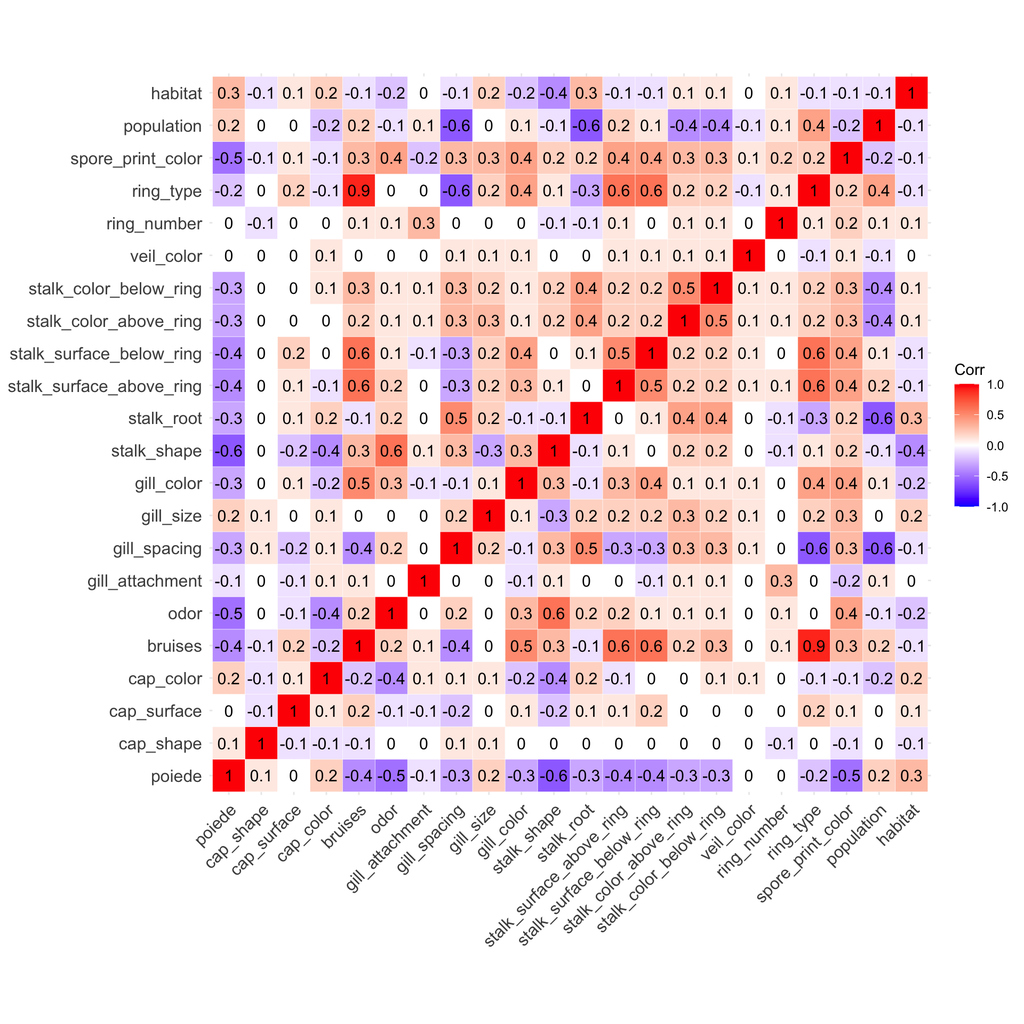

```r
library(ggcorrplot)
corr = round(cor(clean_mushr_id), 1)
ggcorrplot(corr, outline.color = "white",lab = T,lab_size =4)
```